# Homework-2

`ANN training in Keras or Pytorch & Hyper-parameter tuning`

## Overview

- Classification is one of the most common forms of supervised machine learning
- In this homework we will explore “model tuning” for the case of a multi-class classification problem, as applied the MNIST data set
- `You can do this assignment in either Keras OR PyTorch` (or both), it is your choice.

## Submission

- You need to upload TWO documents to Canvas when you are done
  - 1. A PDF (or HTML) of the completed form of the `HW-2.ipynb` document
- The final uploaded version should NOT have any code-errors present
- All outputs must be visible in the uploaded version, including code-cell outputs, images, graphs, etc

`IMPORTANT`: THERE ARE MANY WAYS TO DO THIS, SO FEEL FREE TO DEVIATE SLIGHTLY FROM THE EXACT DETAILS, BUT THE OVERALL RESULT AND FLOW SHOULD MATCH WHAT IS OUTLINED BELOW.

### quick question

The submission details say we need to upload two documents but then only list one? is the pdf/html as well as the ipynb?

## HW-2.1: Data preparation

- Normalize the data as needed
- Partition data into training, validation, and test (i.e. leave one out CV)
  - One option to do this is to give these arrays global scope so they are seen inside the training function (so they don’t need to be passed to functions)
- **Optional but recommended:** Create a K-fold cross validation data set, rather than just doing leave one out
- Do any other preprocessing you feel is needed

### Using Fashion MNIST

99.999% sure Dr. Hickman said it was ok to use Fashion MNIST instead of regular MNIST, which I will be doing.

```python
import torch
from torch import nn

import torchvision
from torchvision import transforms
from torchvision import datasets
from torchvision.transforms import ToTensor

from tqdm.auto import tqdm

import numpy as np
```

Normalizing the data below using ToTensor()

```python
train_data = datasets.FashionMNIST(
    root="data",
    train=True,
    download=True,
    transform=torchvision.transforms.ToTensor(),
    target_transform=None
)

test_data = datasets.FashionMNIST(
    root="data",
    train=False,
    download=True,
    transform=ToTensor(),
    target_transform=None
)

class_names = train_data.classes
```

```python
print(class_names)
```

```
['T-shirt/top', 'Trouser', 'Pullover', 'Dress', 'Coat', 'Sandal', 'Shirt', 'Sneaker', 'Bag', 'Ankle boot']
```

```python
print(f'Length Train: {len(train_data)}')
print(f'Length Test: {len(test_data)}')
```

```
Length Train: 60000
Length Test: 10000
```

```python
from torch.utils.data import random_split

train_size = .9 * len(train_data)
val_size = len(train_data) - train_size

#make val 10% of train
train_data, val_data = random_split(train_data, lengths=[.9, .1])
```

Little heavy on the test data, so I went with just 10% of the traing data for validation

```python
print(f'Length Train: {len(train_data)}')
print(f'Length Val: {len(val_data)}')
```

```
Length Train: 54000
Length Val: 6000
```

```python
from torch.utils.data import DataLoader
BATCH_SIZE = 32

train_dataloader = DataLoader(dataset=train_data,
                              batch_size=BATCH_SIZE,
                              shuffle=True)

val_dataloader = DataLoader(dataset=val_data,
                            batch_size=BATCH_SIZE,
                            shuffle=True)

test_dataloader = DataLoader(dataset=test_data,
                              batch_size=BATCH_SIZE)

train_dataloader, val_dataloader, test_dataloader
```

```
(<torch.utils.data.dataloader.DataLoader at 0x226c1770e90>,
 <torch.utils.data.dataloader.DataLoader at 0x226c156c790>,
 <torch.utils.data.dataloader.DataLoader at 0x226c1771bd0>)
```

```python
print(torch.__version__)
```

```
2.2.1+cu121
```

```python
device = torch.device("cuda" if torch.cuda.is_available() else "cpu")
device
```

```
device(type='cuda')
```

Doing some visualization and shape printing below to make sure is loaded as expected.

```python
import random
random.seed(42)
train_samples = []
train_labels = []

val_samples = []
val_labels = []

test_samples = []
test_labels = []
for sample, label in random.sample(list(train_data), k=3):
  train_samples.append(sample)
  train_labels.append(label)

for sample, label in random.sample(list(val_data), k=3):
  val_samples.append(sample)
  val_labels.append(label)

for sample, label in random.sample(list(test_data), k=3):
  test_samples.append(sample)
  test_labels.append(label)
```

```python
print(f'train length: {len(train_samples)}')
print(f'val shape 0: {val_samples[0].shape}')
print(f'test shape 2: {test_samples[2].shape}')
```

```
train length: 3
val shape 0: torch.Size([1, 28, 28])
test shape 2: torch.Size([1, 28, 28])
```

Going to do a little visualization just to make sure the data is how I expect

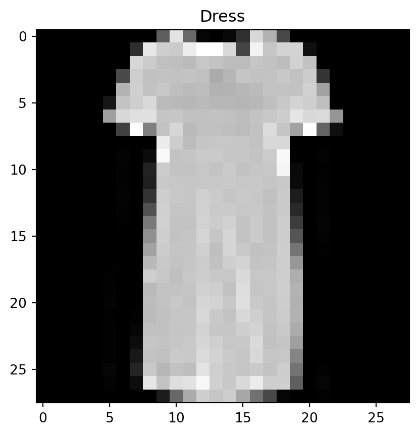

```python
import matplotlib.pyplot as plt
import seaborn as sns

plt.imshow(train_samples[0].squeeze(), cmap='gray')
plt.title(class_names[train_labels[0]])
```

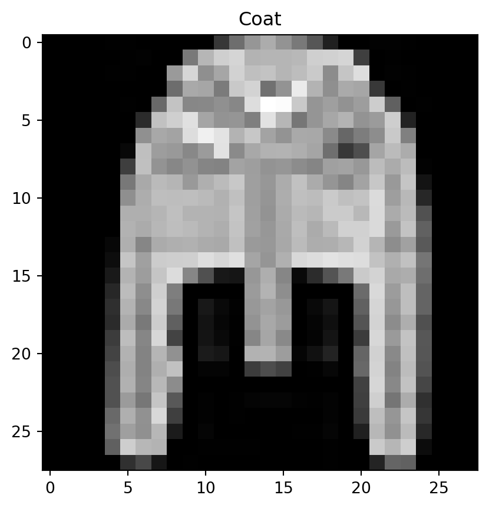

```python
plt.imshow(val_samples[0].squeeze(), cmap='gray')
plt.title(class_names[val_labels[0]])
```

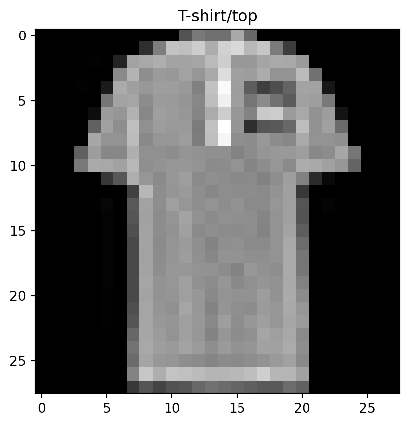

```python
plt.imshow(test_samples[0].squeeze(), cmap='gray')
plt.title(class_names[test_labels[0]])
```

## HW-2.2: Generalized model

- Create a `General` model function (or class) that takes hyper-parameters and evaluates the model
  - The function should work with a set of hyper parameters than can be easily be controlled and varied by the user (for later parameter tuning)
  - This should work for the training, test, and validation set
- Feel free to recycle code from the lab assignments and demo’s
- Use the deep learning best practices that we discussed in class.
- Document what is going on in the code, as needed, with narrative markdown text between cells.

Going to use a resnet like architecture for the model.

```python
import torch.nn as nn

class BasicResBlock(nn.Module):
    def __init__(self, in_channels, out_channels, stride=1, dropout=0.15, padding=1, activation='relu'):
        super().__init__()
        self.conv1 = nn.Conv2d(in_channels, out_channels, kernel_size=3, stride=stride, padding=padding, bias=False)
        self.bn1 = nn.BatchNorm2d(out_channels)
        if activation == 'relu':
          self.activation = nn.ReLU(inplace=True)
        elif activation == 'sigmoid':
          self.activation = nn.Sigmoid()
        elif activation == 'tanh':
          self.activation = nn.Tanh()
        else:
          print(f'Activation Given: {activation}')
          print(type(activation))
          raise ValueError("Activation Function Must Be relu or sigmoid")
        self.dropout = nn.Dropout(p=dropout)

        self.conv2 = nn.Conv2d(out_channels, out_channels, kernel_size=3, stride=1, padding=padding, bias=False)
        self.bn2 = nn.BatchNorm2d(out_channels)

        self.shortcut = nn.Sequential()
        if stride != 1 or in_channels != out_channels:
            self.shortcut = nn.Sequential(
                nn.Conv2d(in_channels, out_channels, kernel_size=1, stride=stride, bias=False),
                nn.BatchNorm2d(out_channels)
            )

    def forward(self, x):
        out = self.conv1(x)
        out = self.bn1(out)
        out = self.activation(out)
        out = self.dropout(out)

        out = self.conv2(out)
        out = self.bn2(out)

        shortcut = self.shortcut(x)

        out += shortcut
        out = self.activation(out)
        return out


class FashionMNISTResNet(nn.Module):
    def __init__(self, input_shape, channels, output_shape, num_layers, activation='relu', dropout=.15):
        super().__init__()
        self.activation = nn.ReLU(inplace=True) if activation == 'relu' else nn.Sigmoid() if activation == 'sigmoid' else nn.Tanh()

        #init the layers with conv2d and batchnorm2d
        self.layers = nn.ModuleList([
            nn.Conv2d(input_shape, channels[0], kernel_size=3, stride=1, padding=1),
            nn.BatchNorm2d(channels[0]),
            self.activation,
            nn.Dropout(p=dropout)
        ])

        #add in resblocks
        for i in range(num_layers):
            self.layers.append(BasicResBlock(channels[i], channels[min(i+1, len(channels)-1)], activation=activation, dropout=dropout))
            if i < len(channels) - 1:
                self.layers.append(nn.Conv2d(channels[i], channels[i+1], kernel_size=3, stride=2, padding=1))
                self.layers.append(nn.BatchNorm2d(channels[i+1]))
                self.layers.append(self.activation)
                self.layers.append(nn.Dropout(p=dropout))

        #global average pooling
        self.global_avg_pool = nn.AdaptiveAvgPool2d((1, 1))

        #final linear layer
        self.linear = nn.Linear(channels[-1], output_shape)

    def forward(self, x):
        for layer in self.layers:
            x = layer(x)

        x = self.global_avg_pool(x)  #apply global average pooling
        x = x.view(x.size(0), -1)  #flatten
        x = self.linear(x)
        return x

#EDITS TO ADD IN
class FashionMNISTANN(nn.Module):
    def __init__(self, input_size, hidden_size, output_shape, num_layers, activation='relu', dropout=0.15):
        super(FashionMNISTANN, self).__init__()
        self.layers = nn.ModuleList()

        #handle multiple activation functions
        if activation == 'relu':
            self.activation = nn.ReLU()
        elif activation == 'sigmoid':
            self.activation = nn.Sigmoid()
        elif activation == 'tanh':
            self.activation = nn.Tanh()
        else:
            raise ValueError("Unsupported activation function")

        #input
        self.layers.append(nn.Linear(input_size, hidden_size))

        #add hidden layers based on num_layers
        for _ in range(num_layers - 1):
            self.layers.append(self.activation)
            self.layers.append(nn.Dropout(dropout))
            self.layers.append(nn.Linear(hidden_size, hidden_size))

        #final activation and dropout
        self.layers.append(self.activation)
        self.layers.append(nn.Dropout(dropout))

        #linear output layer
        self.layers.append(nn.Linear(hidden_size, output_shape))

    def forward(self, x):
        out = x.view(x.size(0), -1)  #flatten
        for layer in self.layers:
            out = layer(out)
        return out
```

## HW-2.3: Model training function

- You can do this in either a function (or python class), or however you think is best.
- **Create a training function** (or class) that takes hyper-parameter choices and trains the model
  - If you are doing “leave one out”, your training function only needs to do one training per hyper-parameter choice
  - If you are doing K-fold cross validation, you should train the model K times for each hyper-parameter choice, and report the average result cross the training runs at the end (this is technically a better practice but requires more computation).
  - Use a dense feed forward ANN model, with the correct output layer activation, and correct loss function
  - `You MUST use early stopping` inside the function, otherwise it defeats the point
  - **Have at least the following hyper-parameters as inputs to this function**
    - L1 regularization constant, L2 regularization constant, dropout rate
    - Learning rate
    - Weight Initialization: Fully random vs Xavier Weight Initialization
    - Hidden layer activation function choice (use relu, sigmoid, or tanh)
    - Number and size of ANN hidden layers
    - Optimizer choice, have at least three included (Adam, SGD, or RmsProp)
    - You can wrap all of the hyper-parameter arguments into a dictionary, or do it however you want
  - **Visualization**
    - Include a boolean parameter as a function input that controls whether visualization is created or not
    - If `true`, Monitor training and validation throughout training by plotting
    - Report a confusion matrix
  - Return the final training and validation error (averaged if using K-fold)
    - again, you must use early stopping to report the best training/validation loss without over-fitting
- Depending how you do this, it can be a lot of computation, start small and scale up and consider using Co-lab

Performed 2.3 as a function. All of the mentioned hyperparameters are adjusted during the hyperparameter training below. Also, with Dr Hickman saying we could use fashion MNIST rather than just MNIST I thought it made more sense to use a cnn rather than just a dense feed forward ANN and that it would still acomplish the learning objectives. Additionally, I’m interested in computer vision problems and wanted to take the chance to better understand CNN architectures.

```python
from sklearn.metrics import confusion_matrix

def train_model(model, dataloaders, criterion, num_epochs, optimizer='adam', early_stopping_patience=10, visualize=True, l1_strength=0.0, l2_strength=0.0, lr=0.001, init_type='random'):
    device = torch.device("cuda:0" if torch.cuda.is_available() else "cpu")
    model.to(device)

    optimizer = optimizer.lower()

    if optimizer == 'adam':
        optimizer = torch.optim.Adam(model.parameters(), lr=lr)
    elif optimizer == 'sgd':
        optimizer = torch.optim.SGD(model.parameters(), lr=lr)
    elif optimizer == 'rmsprop':
        optimizer = torch.optim.RMSprop(model.parameters(), lr=lr)
    else:
        raise ValueError("Unsupported optimizer")

    best_model_wts = copy.deepcopy(model.state_dict())
    best_val_loss = float('inf')
    epochs_no_improve = 0  #early stopping counter

    train_losses, val_losses = [], []
    best_confusion_matrix = None
    best_train_loss = float('inf')

    for epoch in range(num_epochs):
        if epoch % 10 == 0:
          print(f'Epoch {epoch+1}/{num_epochs}')
          print('-' * 10)

        for phase in ['train', 'val']:
            if phase == 'train':
                model.train()
            else:
                model.eval()

            running_loss = 0.0
            my_labels, my_preds = [], []

            for inputs, labels in dataloaders[phase]:
                inputs = inputs.to(device)
                labels = labels.to(device)

                #zero the gradients
                optimizer.zero_grad()

                #forward
                with torch.set_grad_enabled(phase == 'train'):
                    outputs = model(inputs)
                    loss = criterion(outputs, labels)

                    #add in l1 and l2 regularization
                    if l1_strength > 0:
                        l1_regularization = torch.tensor(0., requires_grad=True).to(device)
                        for param in model.parameters():
                            l1_regularization = l1_regularization + torch.norm(param, 1)
                        loss += l1_strength * l1_regularization

                    if l2_strength > 0:
                        l2_regularization = torch.tensor(0., requires_grad=True).to(device)
                        for param in model.parameters():
                            l2_regularization = l2_regularization + torch.norm(param, 2)
                        loss += l2_strength * l2_regularization

                    #backward and optimize only if in training phase
                    if phase == 'train':
                        loss.backward()
                        optimizer.step()

                # Statistics
                running_loss += loss.item() * inputs.size(0)

                _, preds = torch.max(outputs, 1)
                my_labels.extend(labels.cpu().numpy())
                my_preds.extend(preds.cpu().numpy())

            epoch_loss = running_loss / len(dataloaders[phase].dataset)
            if epoch % 10 == 0:
              print(f'{phase} Loss: {epoch_loss:.4f}')

            #deep copy the model and implement early stopping
            if phase == 'val':
                val_losses.append(epoch_loss)

                if epoch_loss < best_val_loss:
                    best_val_loss = epoch_loss
                    best_model_wts = copy.deepcopy(model.state_dict())
                    epochs_no_improve = 0
                    best_confusion_matrix = confusion_matrix(my_labels, my_preds)
                else:
                    epochs_no_improve += 1
            else:
                train_losses.append(epoch_loss)
                if epoch_loss < best_train_loss:
                  best_train_loss = epoch_loss

        if epochs_no_improve >= early_stopping_patience:
            print("Stopping Early")
            break

    if visualize:
        plt.plot(train_losses, label='Training loss')
        plt.plot(val_losses, label='Validation loss')
        plt.xlabel('Epochs')
        plt.ylabel('Loss')
        plt.title(f'Training with Learning Rate {lr} and Initialization {init_type}')
        plt.legend()
        plt.show()

    # Load best model weights
    model.load_state_dict(best_model_wts)

    print(best_confusion_matrix)
    return model, best_train_loss, best_val_loss
```

## HW-2.4: Hyper-parameter tuning

- Keep detailed records of hyper-parameter choices and associated training & validation errors
- Think critically and visualize the results of the search as needed
- **Do each of these in a different sub-section of your notebook**
- **Explore hyper-parameter choice-0**
  - for hidden activation=Relu, hidden layers = [32,32], optimizer=adam
  - Vary the learning rate via a grid search pattern
  - Plot training and validation error as a function of the learning rate
  - Repeat this exercise for both random and Xavier weight initialization
- **Explore hyper-parameter choice-1**
  - for hidden activation=relu, hidden layers = [64,64], optimizer=adam
  - Vary L1 and L2 in a 10x10 grid search (without dropout)
  - Plot validation and training error as a function of L1 and L2 regularization in a 2D heatmap
  - Plot the ratio (or difference) of validation to training error as a function of L1 and L2 regularization in a 2D heatmap
- **Explore hyper-parameter choice-2**
  - for hidden activation=sigmoid, hidden layers = [96,96,96], optimizer=**rmsprop**
  - Vary drop-out parameter in a 1x10 grid search (without L1 or L2 regularization)
  - Plot training and validation error as a function of dropout rate
  - Plot the ratio (or difference) of validation to training error as a function of dropout rate
- **Explore hyper-parameter choice-3:**
  - for hidden activation=relu, hidden layers = [96,96,96], optimizer=**adam**
  - Vary drop-out parameter in a 1x10 grid search (without L1 or L2 regularization)
  - Plot training and validation as a function of dropout rate
  - Plot the ratio (or difference) of validation to training error as a function of dropout rate
- `Optional` Systematically search for the best regularization parameters choice (3D search) using random search algorithm
  - (https://en.wikipedia.org/wiki/Random_search)[https://en.wikipedia.org/wiki/Random_search]
  - Try to see how deep you can get the ANN (max hidden layers) without suffering from the vanishing gradient effect
- `Final fit`
  - At the very end, select a best fit model and report, training, validation, and test errors at the very end
  - Make sure your “plotting variable=True” when for the final training

Hyperparameter Choice 0

Resnet Like Model

```
----------
train Loss: 2.0004
val Loss: 1.7320
----------
train Loss: 0.8938
val Loss: 0.7619
----------
train Loss: 0.6457
val Loss: 0.5467
[[479   2   5  36  12   0  43   0   6   0]
 [  0 558   1   9   0   0   2   0   0   0]
 [  4   0 419   1 118   0  32   0   5   0]
 [ 16  19   2 549  21   0  28   0   1   0]
 [  3   2  28  36 509   0  39   0   0   0]
 [  0   0   0   0   0 539   0  56   0   9]
 [113   0  63  25 174   0 188   1   3   0]
 [  0   0   0   0   0   4   0 593   0  18]
 [  0   0   4   6   7   2   4   3 576   1]
 [  0   1   0   0   0   4   0  44   1 576]]
Elapsed Time: 02:54
----------
train Loss: 1.3314
val Loss: 0.8267
----------
train Loss: 0.3630
val Loss: 0.3063
----------
train Loss: 0.2930
val Loss: 0.2487
[[480   1   8  13   0   0  76   0   5   0]
 [  0 567   0   1   1   0   1   0   0   0]
 [  2   1 529   2  25   0  20   0   0   0]
 [ 15   7   4 566  18   0  26   0   0   0]
 [  0   1  19   8 556   0  33   0   0   0]
 [  0   0   0   0   0 581   0  17   0   6]
 [ 38   1  34   2  45   0 447   0   0   0]
 [  0   0   0   0   0   0   0 594   0  21]
 [  0   0   2   0   1   0   1   1 598   0]
 [  0   0   0   0   0   0   0  13   0 613]]
Elapsed Time: 05:48
```

[output cut: 62 more lines]

```
----------
train Loss: 0.2452
val Loss: 0.2108
Stopping Early
[[501   1   4  14   0   0  56   0   7   0]
 [  0 566   0   3   1   0   0   0   0   0]
 [  4   0 525   5  16   0  29   0   0   0]
 [ 13   2   2 599  10   0  10   0   0   0]
 [  2   2  21  19 537   0  36   0   0   0]
 [  0   0   0   0   0 582   0  14   0   8]
 [ 49   0  18  14  25   0 461   0   0   0]
 [  0   0   0   0   0   0   0 604   0  11]
 [  0   0   1   1   1   0   1   0 599   0]
 [  0   0   0   0   0   0   0  19   0 607]]
Elapsed Time: 07:42
```

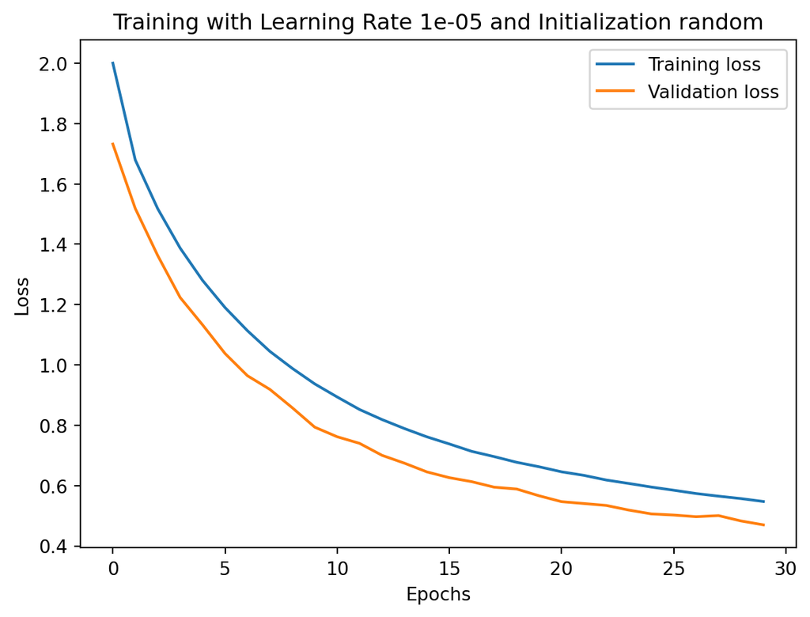

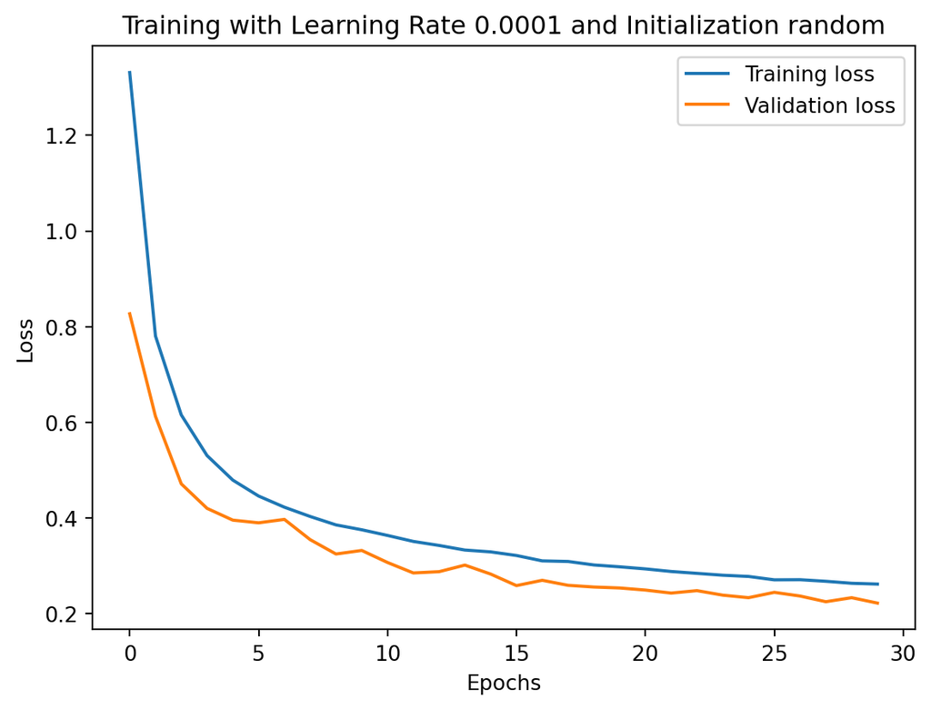

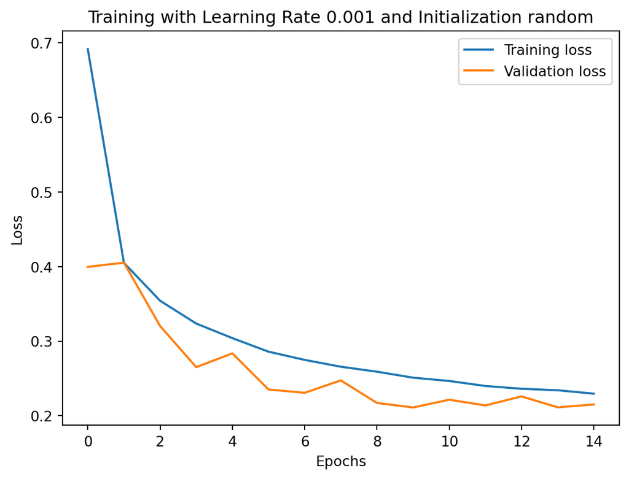

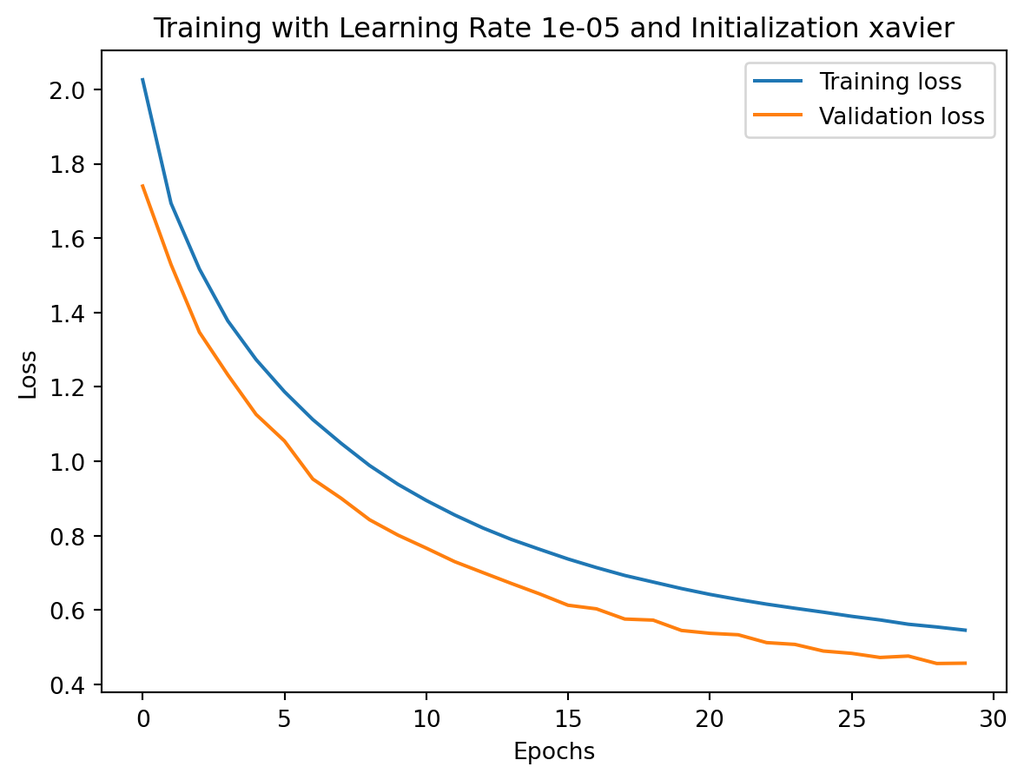

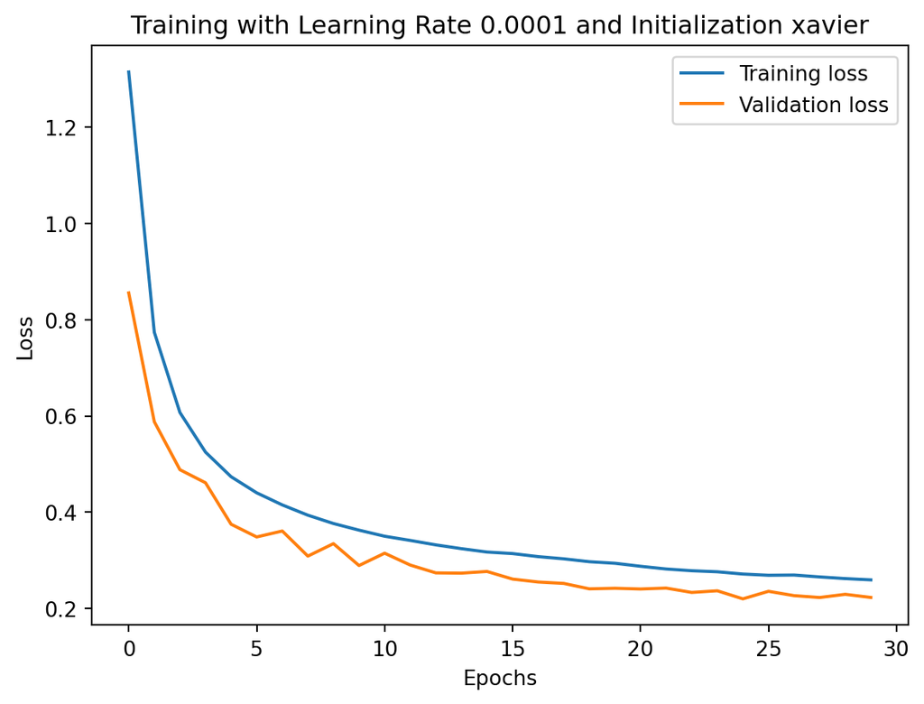

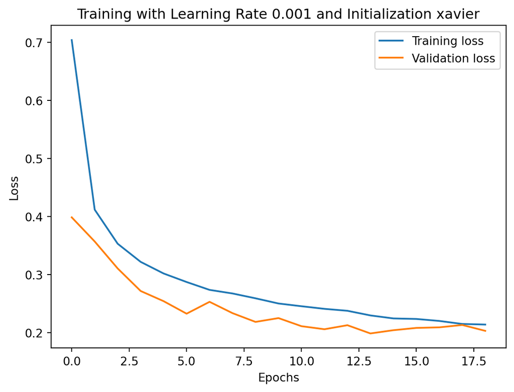

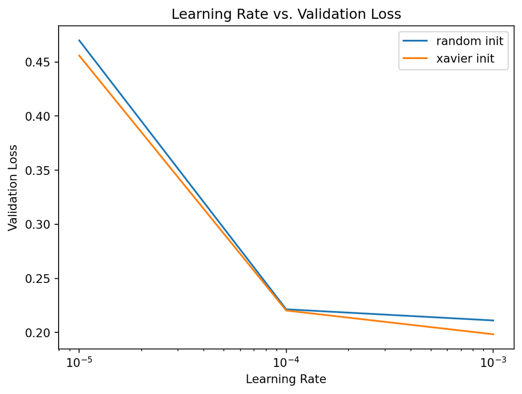

```python
import copy
from collections import defaultdict
import torch.optim as optim
import time



#initialize model
def init_weights(m, init_type="random"):
    if isinstance(m, nn.Conv2d) or isinstance(m, nn.Linear):
        if init_type == "xavier":
            nn.init.xavier_uniform_(m.weight)
        else:
            nn.init.uniform_(m.weight, -0.1, 0.1)
        if m.bias is not None:
            nn.init.constant_(m.bias, 0)

learning_rates = [.00001, .0001, .001]
init_types = ["random", "xavier"]
results = defaultdict(list)
my_activation = "relu"

criterion = nn.CrossEntropyLoss()

for init_type in init_types:
    start_time = time.time()
    for lr in learning_rates:
        model = FashionMNISTResNet(input_shape=1, channels=[32, 32], output_shape=10, activation=my_activation, num_layers=2, dropout=.15)

        #train model
        trained_model, best_train_loss, best_val_loss = train_model(model, {'train': train_dataloader, 'val': val_dataloader},
                                                   criterion=criterion, optimizer='adam',
                                                   num_epochs=30, early_stopping_patience=5, visualize=True, lr=lr, init_type=init_type)

        #save results
        results[init_type].append({'lr': lr, 'best_val_loss': best_val_loss})

        #print time in mm:ss
        print(f'Elapsed Time: {time.strftime("%M:%S", time.gmtime(time.time() - start_time))}')

#visualize
for init_type in init_types:
    lrs = [result['lr'] for result in results[init_type]]
    losses = [result['best_val_loss'] for result in results[init_type]]
    plt.plot(lrs, losses, label=f"{init_type} init")
plt.xscale('log')
plt.xlabel('Learning Rate')
plt.ylabel('Validation Loss')
plt.legend()
plt.title('Learning Rate vs. Validation Loss')
plt.show()
```

### Deep Feed Forward ANN

```
----------
train Loss: 2.2409
val Loss: 2.1259
----------
train Loss: 0.9537
val Loss: 0.8109
----------
train Loss: 0.7858
val Loss: 0.6618
[[476   7   7  46   2   0  32   0  13   0]
 [  1 544   7  16   0   0   2   0   0   0]
 [  6   1 382   2 137   0  41   0  10   0]
 [ 41   9   3 537  21   0  25   0   0   0]
 [  1   2  71  37 474   0  25   0   7   0]
 [  0   0   0   0   0 453   0 101   1  49]
 [123   1  76  24 182   0 143   0  17   1]
 [  0   0   0   0   0  15   0 549   0  51]
 [  1   0   2   6   2   0   8   0 584   0]
 [  0   0   0   0   0   4   0  37   0 585]]
Elapsed Time: 02:05
----------
train Loss: 1.3171
val Loss: 0.7951
----------
train Loss: 0.4946
val Loss: 0.4081
----------
train Loss: 0.4208
val Loss: 0.3603
[[512   2  10  15   0   0  36   0   8   0]
 [  3 556   0  10   0   0   1   0   0   0]
 [  7   0 476   4  72   0  18   0   2   0]
 [ 28   4   5 563  20   0  16   0   0   0]
 [  1   1  60  18 497   0  40   0   0   0]
 [  0   0   0   0   0 565   0  18   3  18]
 [ 83   1  71  10  63   0 332   0   6   1]
 [  0   0   0   0   0  21   0 581   0  13]
 [  0   0   1   1   3   3   7   0 588   0]
 [  0   0   0   0   0   5   0  27   0 594]]
Elapsed Time: 02:06
```

[output cut: 64 more lines]

```
----------
train Loss: 0.3537
val Loss: 0.3331
Stopping Early
[[493   2   4  23   1   0  53   0   7   0]
 [  2 553   2  10   1   0   2   0   0   0]
 [  5   0 477   5  67   0  21   0   4   0]
 [ 21   2   5 568  26   0  14   0   0   0]
 [  2   0  52  12 513   0  37   0   1   0]
 [  0   0   0   0   0 570   0  20   2  12]
 [ 74   1  61  18  64   0 343   0   5   1]
 [  0   0   0   0   0  10   0 595   1   9]
 [  0   0   1   1   2   0   9   0 590   0]
 [  1   0   0   0   0   4   0  26   1 594]]
Elapsed Time: 01:54
```

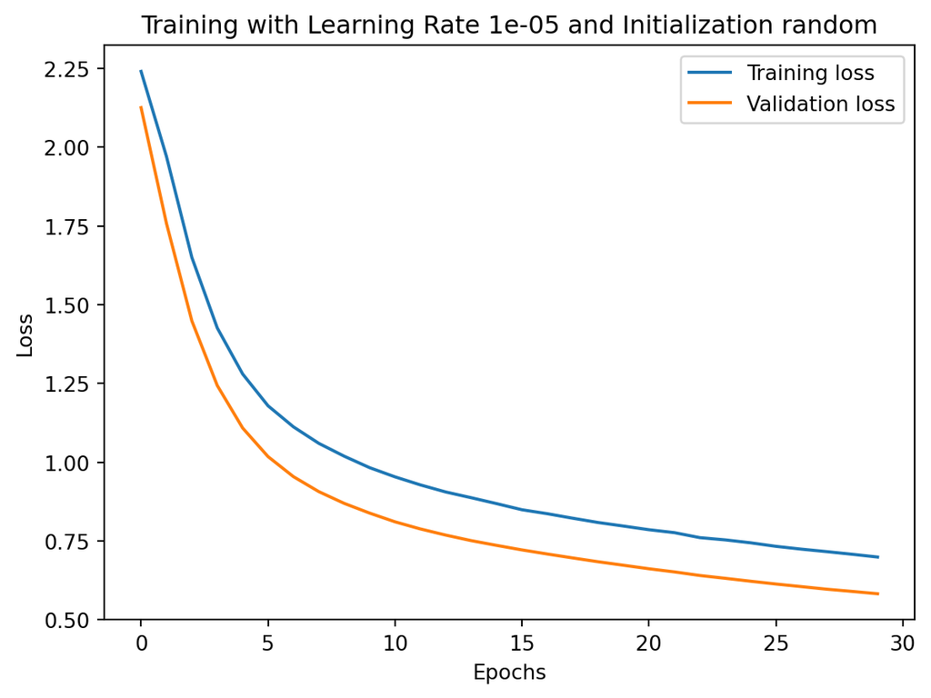

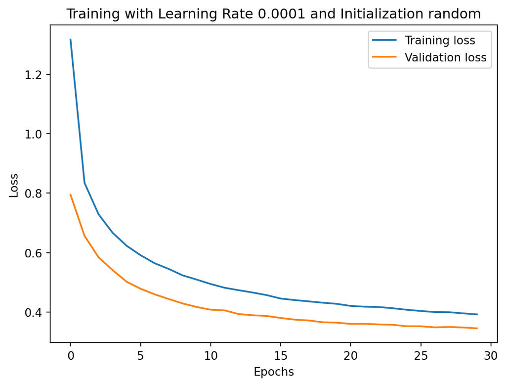

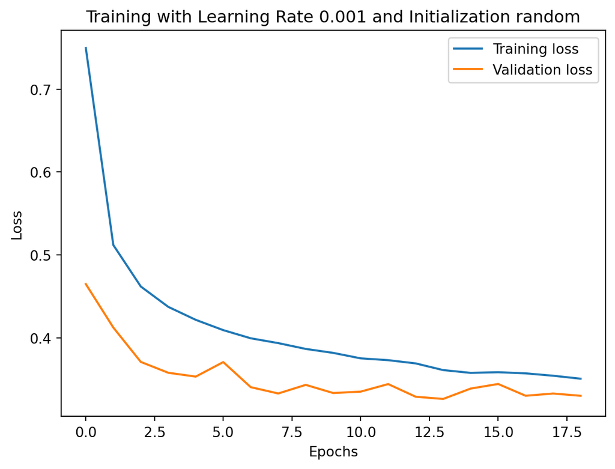

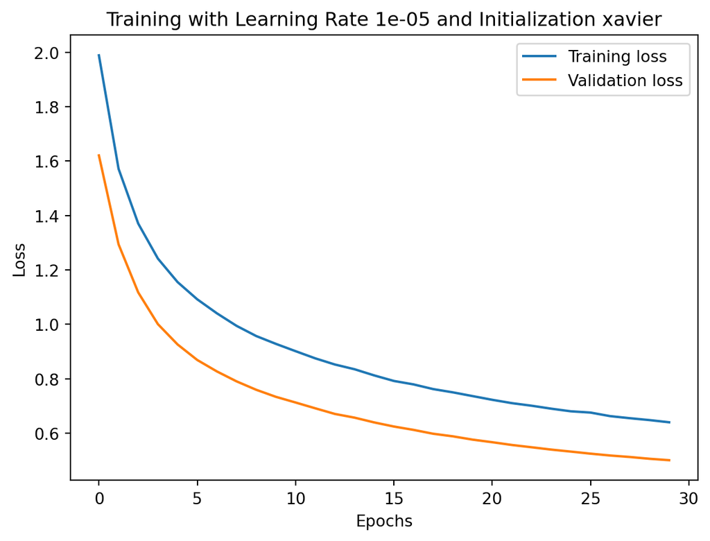

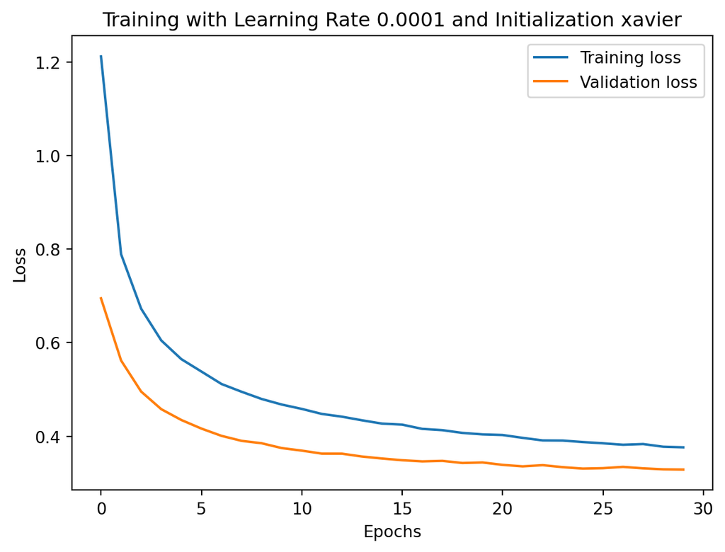

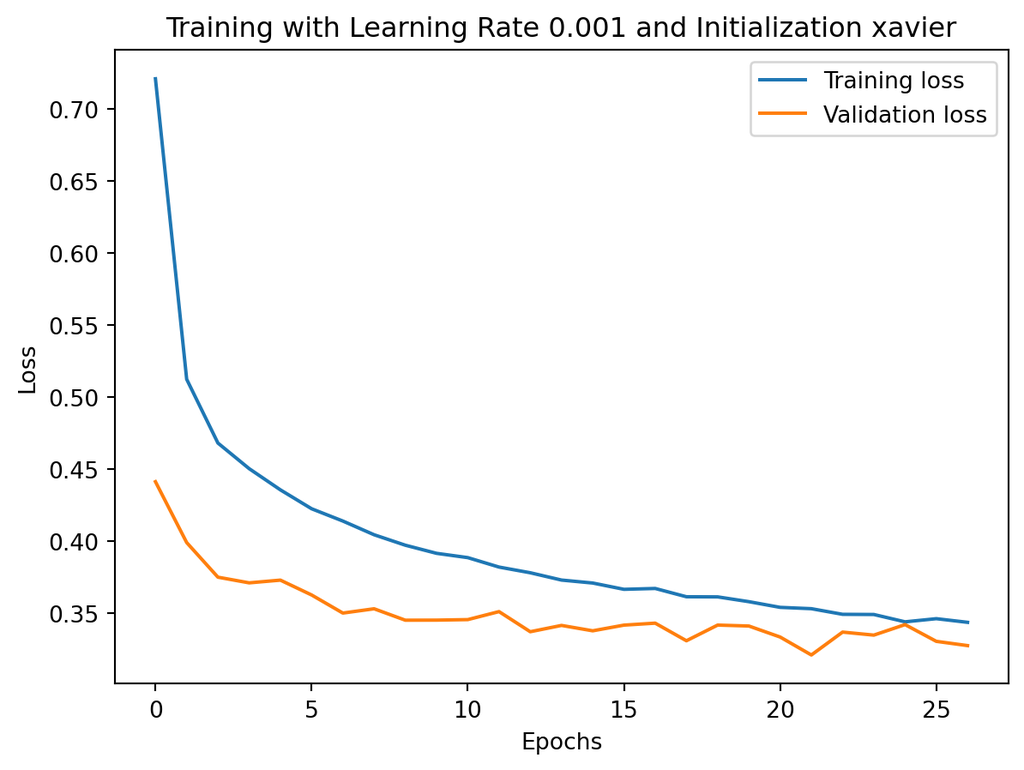

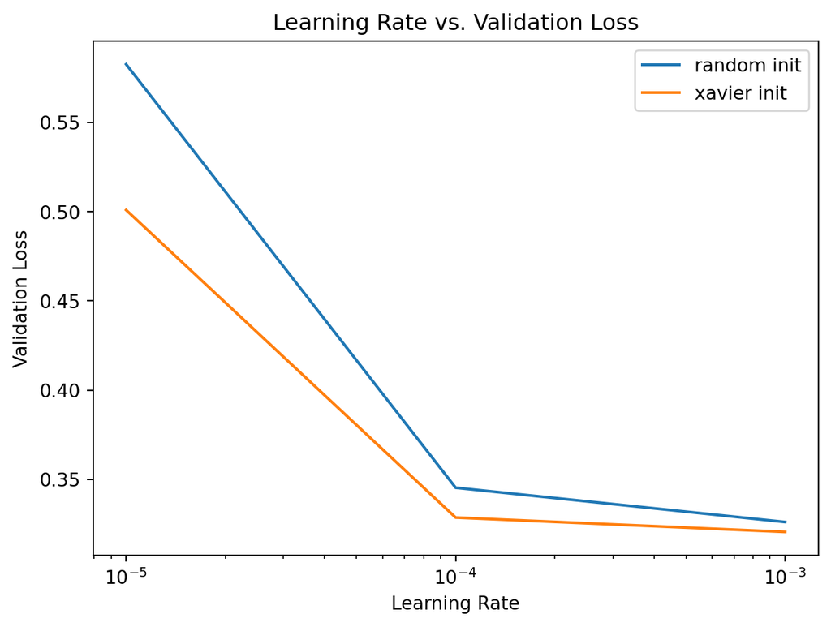

```python
#duplicated so I can test models independently
import copy
from collections import defaultdict
import torch.optim as optim
import time

#initialize model
def init_weights(m, init_type="random"):
    if isinstance(m, nn.Conv2d) or isinstance(m, nn.Linear):
        if init_type == "xavier":
            nn.init.xavier_uniform_(m.weight)
        else:
            nn.init.uniform_(m.weight, -0.1, 0.1)
        if m.bias is not None:
            nn.init.constant_(m.bias, 0)



learning_rates = [.00001, .0001, .001]
init_types = ["random", "xavier"]
results = defaultdict(list)
my_activation = "relu"

criterion = nn.CrossEntropyLoss()

#EDITS TO ADD IN
ann_in_size = 28*28
ann_hidden_size = 32 #not sure if the intent was to have the hidden size take a list, but since all of the sizes are the same I'll just use an int and avoid the added work to accept a list of sizes
ann_len = 2

for init_type in init_types:
    for lr in learning_rates:
        start_time = time.time()

        model = FashionMNISTANN(input_size=ann_in_size, hidden_size=ann_hidden_size, output_shape=10, activation=my_activation, num_layers=ann_len, dropout=.15)
        model.apply(lambda m: init_weights(m, init_type=init_type))

        #train model
        trained_model, best_train_loss, best_val_loss = train_model(model, {'train': train_dataloader, 'val': val_dataloader},
                                                   criterion=criterion, optimizer='adam',
                                                   num_epochs=30, early_stopping_patience=5, visualize=True, lr=lr, init_type=init_type)

        #save results
        results[init_type].append({'lr': lr, 'best_val_loss': best_val_loss})
        #print elapsed time with two decimal places formated in mm:ss
        print(f'Elapsed Time: {time.strftime("%M:%S", time.gmtime(time.time() - start_time))}')

#visualize
for init_type in init_types:
    lrs = [result['lr'] for result in results[init_type]]
    losses = [result['best_val_loss'] for result in results[init_type]]
    plt.plot(lrs, losses, label=f"{init_type} init")
plt.xscale('log')
plt.xlabel('Learning Rate')
plt.ylabel('Validation Loss')
plt.legend()
plt.title('Learning Rate vs. Validation Loss')
plt.show()
```

Hyperparameter Tuning 1

```
Training with L1 strength: 0.0001
Training with L2 strength: 0.0001
----------
train Loss: 1.4542
val Loss: 1.1887
[[499   0   2  26   0   1  48   0   7   0]
 [  0 553   1  14   0   0   2   0   0   0]
 [ 10   0 385   1  40   0 135   0   8   0]
 [ 26   2   1 566   4   0  37   0   0   0]
 [  2   1   7  34 412   0 158   0   3   0]
 [  0   0   0   0   0 581   0  11   0  12]
 [105   0  17  14  37   1 386   0   7   0]
 [  0   0   0   0   0  26   0 514   0  75]
 [  1   0   1   3   3   1   1   0 593   0]
 [  0   0   0   1   0   0   0   5   1 619]]
Elapsed Time: 15.481550455093384
Training with L2 strength: 0.00021544346900318845
----------
train Loss: 1.4429
val Loss: 1.1374
[[510   7  10   3   0   4  39   0  10   0]
 [  1 567   1   0   0   0   0   0   1   0]
 [  5   1 545   0   2   2  20   0   4   0]
 [ 65  68   9 421   1   1  50   0  21   0]
 [  6   6 169  26 271   1 136   0   2   0]
 [  0   0   0   0   0 597   0   3   0   4]
 [112   4  83   3  15   2 340   0   8   0]
 [  0   0   0   0   0 164   0 384   9  58]
 [  0   0   6   0   0   2   4   0 591   0]
 [  0   1   0   0   0  13   0   5   2 605]]
Elapsed Time: 15.349195003509521
Training with L2 strength: 0.00046415888336127773
----------
train Loss: 1.4263
val Loss: 1.1285
[[467   1  17  24  14   1  53   0   6   0]
 [  1 559   2   6   2   0   0   0   0   0]
 [  4   0 512   2  42   0  16   0   3   0]
 [ 11   7   8 515  74   0  20   0   1   0]
 [  2   1  36  12 554   0  12   0   0   0]
```

[output cut: 1455 more lines]

```
Training with L2 strength: 0.1
----------
train Loss: 138.9914
val Loss: 36.3908
[[  0 319   0   0   0  30   0   0 234   0]
 [  0 566   0   0   0   1   0   0   3   0]
 [  0 380   0   0   0   4   0   0 195   0]
 [  0 467   0   0   0  51   0   0 118   0]
 [  0 372   0   0   0   7   0   0 238   0]
 [  0   0   0   0   0 545   0  22  37   0]
 [  0 239   0   0   0  17   0   0 311   0]
 [  0   0   0   0   0  91   0 509  15   0]
 [  0   2   0   0   0  12   0   0 589   0]
 [  0  13   0   0   0  62   0  42 509   0]]
Elapsed Time: 15.398979187011719
```

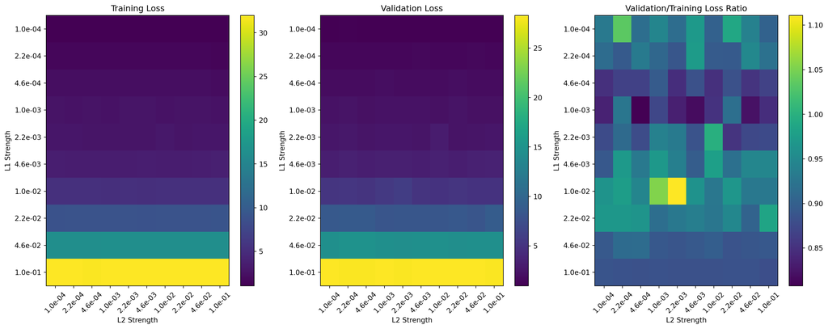

```python
lr = 0.0001
init_type = 'xavier'


#hyperparameters for grid search
l1_values = np.logspace(-4, -1, 10)
l2_values = np.logspace(-4, -1, 10)

results = defaultdict(lambda: defaultdict(dict))

for l1_strength in l1_values:
    print(f"Training with L1 strength: {l1_strength}")
    for l2_strength in l2_values:
        start_time = time.time()
        print(f"Training with L2 strength: {l2_strength}")
        model = FashionMNISTResNet(input_shape=1, channels=[64, 64], output_shape=10, num_layers=2, activation=my_activation, dropout=0)
        model.apply(lambda m: init_weights(m, init_type='xavier'))

        #train model with L1 regularization
        trained_model, train_loss, val_loss = train_model(model, {'train': train_dataloader, 'val': val_dataloader},
                                                          criterion=criterion, optimizer='adam', num_epochs=2, lr=lr, init_type=init_type, l1_strength=l1_strength, early_stopping_patience=5, visualize=False)

        #store results
        results[l1_strength][l2_strength]['train_loss'] = train_loss
        results[l1_strength][l2_strength]['val_loss'] = val_loss

        print(f'Elapsed Time: {time.time() - start_time}')

#convert results to numpy arrays for plotting
train_losses = np.array([[results[l1][l2]['train_loss'] for l2 in l2_values] for l1 in l1_values])
val_losses = np.array([[results[l1][l2]['val_loss'] for l2 in l2_values] for l1 in l1_values])

#plotting
fig, ax = plt.subplots(1, 3, figsize=(20, 7))

#training loss
c1 = ax[0].imshow(train_losses, cmap='viridis', aspect='auto')
ax[0].set_title('Training Loss')
ax[0].set_xlabel('L2 Strength')
ax[0].set_ylabel('L1 Strength')
ax[0].set_xticks(range(len(l2_values)))
ax[0].set_yticks(range(len(l1_values)))
ax[0].set_xticklabels([f"{val:.1e}" for val in l2_values], rotation=45)
ax[0].set_yticklabels([f"{val:.1e}" for val in l1_values])
fig.colorbar(c1, ax=ax[0])

#validation loss
c2 = ax[1].imshow(val_losses, cmap='viridis', aspect='auto')
ax[1].set_title('Validation Loss')
ax[1].set_xlabel('L2 Strength')
ax[1].set_ylabel('L1 Strength')
ax[1].set_xticks(range(len(l2_values)))
ax[1].set_yticks(range(len(l1_values)))
ax[1].set_xticklabels([f"{val:.1e}" for val in l2_values], rotation=45)
ax[1].set_yticklabels([f"{val:.1e}" for val in l1_values])
fig.colorbar(c2, ax=ax[1])

#validation/training loss ratio
ratio = val_losses / train_losses
c3 = ax[2].imshow(ratio, cmap='viridis', aspect='auto')
ax[2].set_title('Validation/Training Loss Ratio')
ax[2].set_xlabel('L2 Strength')
ax[2].set_ylabel('L1 Strength')
ax[2].set_xticks(range(len(l2_values)))
ax[2].set_yticks(range(len(l1_values)))
ax[2].set_xticklabels([f"{val:.1e}" for val in l2_values], rotation=45)
ax[2].set_yticklabels([f"{val:.1e}" for val in l1_values])
fig.colorbar(c3, ax=ax[2])

plt.show()
```

```
Training with L1 strength: 0.0001
Training with L2 strength: 0.0001
----------
train Loss: 1.2270
val Loss: 0.7894
[[476   3   9  43   2   0  36   0  14   0]
 [  2 546   3  18   0   0   1   0   0   0]
 [  3   1 408   3 122   0  30   0  12   0]
 [ 33   6   6 554  24   0  13   0   0   0]
 [  2   0  55  23 492   0  38   0   7   0]
 [  0   0   0   0   0 542   0  27   3  32]
 [101   1  72  23  96   0 262   0  11   1]
 [  0   0   0   0   0  32   0 539   1  43]
 [  0   0   2   8   3   0   6   1 583   0]
 [  0   0   0   1   0   7   0  20   0 598]]
Elapsed Time: 00:09
Training with L2 strength: 0.00021544346900318845
----------
train Loss: 1.2902
val Loss: 0.8128
[[479   5  11  46   1   0  28   0  11   2]
 [  1 548   5  14   0   0   2   0   0   0]
 [  5   1 471   6  66   0  19   0  11   0]
 [ 25   7  11 566  16   0   9   0   2   0]
 [  2   1  95  35 444   0  33   0   7   0]
 [  0   0   0   0   0 520   0  43   4  37]
 [110   1  84  31  67   0 256   0  17   1]
 [  0   0   0   0   0  20   0 539   1  55]
 [  0   0   4   6   4   0   3   1 585   0]
 [  0   0   0   0   0   5   0  21   0 600]]
Elapsed Time: 00:19
Training with L2 strength: 0.00046415888336127773
----------
train Loss: 1.2579
val Loss: 0.8005
[[461   4  12  43   2   0  46   0  14   1]
 [  1 543   7  17   0   0   2   0   0   0]
 [  3   0 454   2  79   0  32   0   9   0]
 [ 21   2  11 560  25   0  16   0   1   0]
 [  1   0  69  27 470   0  45   0   5   0]
```

[output cut: 1455 more lines]

```
Training with L2 strength: 0.1
----------
train Loss: 61.5488
val Loss: 6.1637
[[  0   0 583   0   0   0   0   0   0   0]
 [  0   0 570   0   0   0   0   0   0   0]
 [  0   0 579   0   0   0   0   0   0   0]
 [  0   0 636   0   0   0   0   0   0   0]
 [  0   0 617   0   0   0   0   0   0   0]
 [  0   0 604   0   0   0   0   0   0   0]
 [  0   0 567   0   0   0   0   0   0   0]
 [  0   0 615   0   0   0   0   0   0   0]
 [  0   0 603   0   0   0   0   0   0   0]
 [  0   0 626   0   0   0   0   0   0   0]]
Elapsed Time: 01:42
```

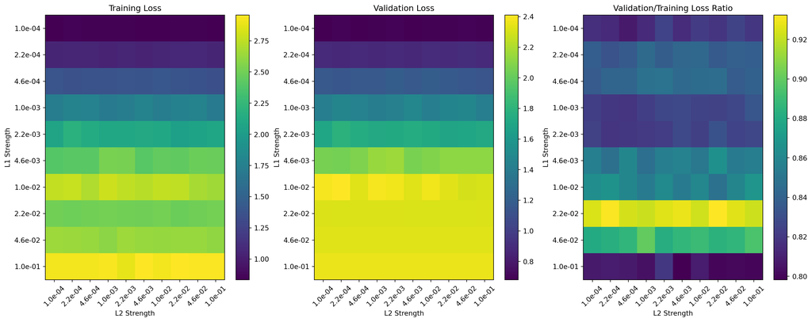

```python
lr = 0.0001
init_type = 'xavier'


#hyperparameters for grid search
l1_values = np.logspace(-4, -1, 10)
l2_values = np.logspace(-4, -1, 10)

results = defaultdict(lambda: defaultdict(dict))

#some of these are just restated for clarity
ann_in_size = 28*28
ann_hidden_size = 64
ann_len = 2

for l1_strength in l1_values:
    print(f"Training with L1 strength: {l1_strength}")
    start_time = time.time()
    for l2_strength in l2_values:
        print(f"Training with L2 strength: {l2_strength}")
        model = FashionMNISTANN(input_size=ann_in_size, hidden_size=ann_hidden_size, output_shape=10, activation=my_activation, num_layers=ann_len, dropout=.15)
        model.apply(lambda m: init_weights(m, init_type='xavier'))

        #train model with L1 regularization
        trained_model, train_loss, val_loss = train_model(model, {'train': train_dataloader, 'val': val_dataloader},
                                                          criterion=criterion, optimizer='adam', num_epochs=2, lr=lr, init_type=init_type, l1_strength=l1_strength, early_stopping_patience=5, visualize=False)

        #store results
        results[l1_strength][l2_strength]['train_loss'] = train_loss
        results[l1_strength][l2_strength]['val_loss'] = val_loss

        #print elapsed time with two decimal places formated in mm:ss
        print(f'Elapsed Time: {time.strftime("%M:%S", time.gmtime(time.time() - start_time))}')

#convert results to numpy arrays for plotting
train_losses = np.array([[results[l1][l2]['train_loss'] for l2 in l2_values] for l1 in l1_values])
val_losses = np.array([[results[l1][l2]['val_loss'] for l2 in l2_values] for l1 in l1_values])

#plotting
fig, ax = plt.subplots(1, 3, figsize=(20, 7))

#training loss
c1 = ax[0].imshow(train_losses, cmap='viridis', aspect='auto')
ax[0].set_title('Training Loss')
ax[0].set_xlabel('L2 Strength')
ax[0].set_ylabel('L1 Strength')
ax[0].set_xticks(range(len(l2_values)))
ax[0].set_yticks(range(len(l1_values)))
ax[0].set_xticklabels([f"{val:.1e}" for val in l2_values], rotation=45)
ax[0].set_yticklabels([f"{val:.1e}" for val in l1_values])
fig.colorbar(c1, ax=ax[0])

#validation loss
c2 = ax[1].imshow(val_losses, cmap='viridis', aspect='auto')
ax[1].set_title('Validation Loss')
ax[1].set_xlabel('L2 Strength')
ax[1].set_ylabel('L1 Strength')
ax[1].set_xticks(range(len(l2_values)))
ax[1].set_yticks(range(len(l1_values)))
ax[1].set_xticklabels([f"{val:.1e}" for val in l2_values], rotation=45)
ax[1].set_yticklabels([f"{val:.1e}" for val in l1_values])
fig.colorbar(c2, ax=ax[1])

#validation/training loss ratio
ratio = val_losses / train_losses
c3 = ax[2].imshow(ratio, cmap='viridis', aspect='auto')
ax[2].set_title('Validation/Training Loss Ratio')
ax[2].set_xlabel('L2 Strength')
ax[2].set_ylabel('L1 Strength')
ax[2].set_xticks(range(len(l2_values)))
ax[2].set_yticks(range(len(l1_values)))
ax[2].set_xticklabels([f"{val:.1e}" for val in l2_values], rotation=45)
ax[2].set_yticklabels([f"{val:.1e}" for val in l1_values])
fig.colorbar(c3, ax=ax[2])

plt.show()
```

Hyperparameter Tuning 2

```
----------
train Loss: 0.8644
val Loss: 1.0586
[[337   0   6  16   2   2 208   0  12   0]
 [  0 556   0   8   1   0   3   0   2   0]
 [  0   0 466   2  34   0  72   0   5   0]
 [  2   0   1 561  41   0  29   0   2   0]
 [  0   0   4   4 555   0  52   0   2   0]
 [  0   0   0   0   0 593   0   7   1   3]
 [  5   0   8   5  34   0 512   0   3   0]
 [  0   0   0   0   0   4   0 605   0   6]
 [  0   0   0   0   2   0   2   0 599   0]
 [  0   0   0   0   0   1   0  23   1 601]]
Elapsed Time: 01:07
----------
train Loss: 0.8878
val Loss: 1.6688
[[560   1   5   7   0   0   3   0   7   0]
 [  2 562   0   5   1   0   0   0   0   0]
 [ 11   1 558   2   5   0   0   0   2   0]
 [ 65   3   4 554   8   0   2   0   0   0]
 [  9   1  91  24 476   0  13   0   3   0]
 [  0   0   0   0   0 588   0  14   0   2]
 [176   1 105   6  57   0 216   0   6   0]
 [  0   0   0   0   0   3   0 602   0  10]
 [  2   0   4   1   1   1   1   0 593   0]
 [  0   0   0   2   0   2   0  24   2 596]]
Elapsed Time: 01:09
----------
train Loss: 0.9395
val Loss: 0.9139
[[461   4  17  62   0   0  35   0   4   0]
 [  0 564   0   6   0   0   0   0   0   0]
 [  0   0 540   9  25   0   5   0   0   0]
 [  2   0   2 626   0   0   6   0   0   0]
 [  0   0  27  54 522   0  14   0   0   0]
 [  0   0   0   0   0 551   0  51   0   2]
 [ 41   1  59  51  79   0 336   0   0   0]
 [  0   0   0   0   0   0   0 611   0   4]
 [  1   0  16  14   6   0   2   0 564   0]
```

[output cut: 85 more lines]

```
Elapsed Time: 01:09
----------
train Loss: 1.9171
val Loss: 2.9120
[[433   0   8   8   0   0 126   1   7   0]
 [  6 532   8  15   0   0   9   0   0   0]
 [  0   0 475   1   1   0  96   0   6   0]
 [140   5   4 378   0   0 108   0   1   0]
 [ 23   0 318  16   5   0 251   0   4   0]
 [  1   0   0   0   0 488   1  58  33  23]
 [117   0 255   1   0   0 184   0  10   0]
 [  0   0   0   0   0  23   0 509  19  64]
 [  4   0   5   2   0   0  27   0 565   0]
 [  2   0   0   1   6   3   0  30   3 581]]
Elapsed Time: 01:09
```

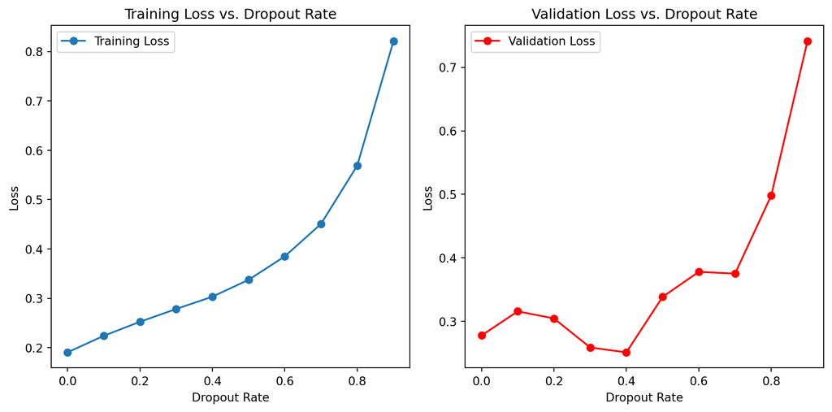

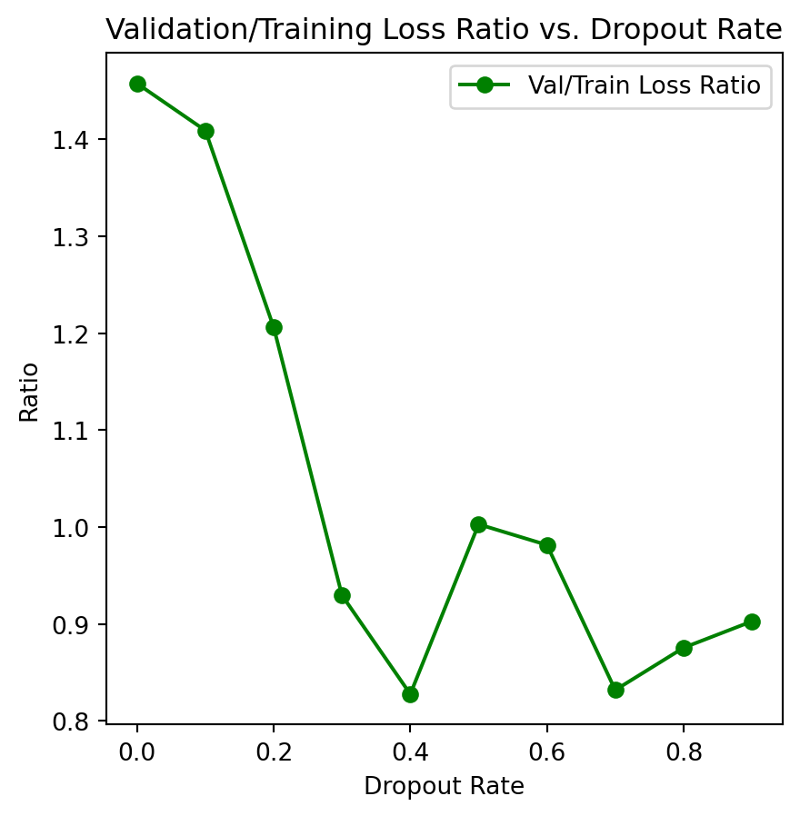

```python
#10 values for dropout
dropout_values = np.linspace(0, 0.9, 10)
results = defaultdict(dict)

for dropout_rate in dropout_values:
    start_time = time.time()

    #init based on hyperparameter choice 2
    model = FashionMNISTResNet(input_shape=1, channels=[96, 96, 96], output_shape=10, num_layers=2, activation='sigmoid', dropout=dropout_rate)
    model.apply(lambda m: init_weights(m, init_type='xavier'))

    optimizer = 'rmsprop'

    #train
    trained_model, train_loss, val_loss = train_model(
        model,
        {'train': train_dataloader, 'val': val_dataloader},
        criterion=criterion,
        optimizer=optimizer,
        num_epochs=10,
        early_stopping_patience=5,
        visualize=False,
        l1_strength=0.0,
        l2_strength=0.0,
    )

    #save results
    results[dropout_rate]['train_loss'] = train_loss
    results[dropout_rate]['val_loss'] = val_loss

    #print elapsed time with two decimal places formated in mm:ss
    print(f'Elapsed Time: {time.strftime("%M:%S", time.gmtime(time.time() - start_time))}')

dropout_rates = np.array(list(results.keys()))
train_losses = np.array([results[rate]['train_loss'] for rate in dropout_rates])
val_losses = np.array([results[rate]['val_loss'] for rate in dropout_rates])

plt.figure(figsize=(10, 5))

#training loss plot
plt.subplot(1, 2, 1)
plt.plot(dropout_rates, train_losses, marker='o', label='Training Loss')
plt.xlabel('Dropout Rate')
plt.ylabel('Loss')
plt.title('Training Loss vs. Dropout Rate')
plt.legend()

#validation loss plot
plt.subplot(1, 2, 2)
plt.plot(dropout_rates, val_losses, marker='o', color='r', label='Validation Loss')
plt.xlabel('Dropout Rate')
plt.ylabel('Loss')
plt.title('Validation Loss vs. Dropout Rate')
plt.legend()

plt.tight_layout()
plt.show()

#plotting the ratio
ratio = val_losses / train_losses
plt.figure(figsize=(5, 5))
plt.plot(dropout_rates, ratio, marker='o', color='g', label='Val/Train Loss Ratio')
plt.xlabel('Dropout Rate')
plt.ylabel('Ratio')
plt.title('Validation/Training Loss Ratio vs. Dropout Rate')
plt.legend()
plt.show()
```

```
----------
train Loss: 0.6452
val Loss: 0.4253
[[477   2   7  29   0   1  57   0  10   0]
 [  1 560   1   7   0   0   0   0   1   0]
 [  1   0 496   3  60   0  18   0   1   0]
 [ 10   7   6 585  21   0   7   0   0   0]
 [  1   0  49  17 520   0  30   0   0   0]
 [  0   0   0   0   0 562   0  28   3  11]
 [ 50   0  59  12  49   0 389   0   7   1]
 [  0   0   0   0   0   8   0 594   1  12]
 [  0   0   0   1   2   0   1   0 599   0]
 [  0   0   0   0   0   3   0  22   0 601]]
Elapsed Time: 00:42
----------
train Loss: 0.7091
val Loss: 0.4577
[[491   2   5  23   0   0  54   0   8   0]
 [  1 559   0   9   0   0   1   0   0   0]
 [  3   0 437   4  92   0  41   0   2   0]
 [ 19   4   4 579  15   0  15   0   0   0]
 [  2   0  37  20 526   0  30   0   2   0]
 [  1   0   0   0   0 581   0  13   0   9]
 [ 67   0  35  11  67   0 381   0   5   1]
 [  0   0   0   0   0  13   0 573   0  29]
 [  1   0   0   3   3   1   3   0 592   0]
 [  0   0   0   0   0   4   0  14   0 608]]
Elapsed Time: 00:43
----------
train Loss: 0.7790
val Loss: 0.4666
[[513   0   7  18   0   1  38   0   6   0]
 [  2 553   0  13   0   0   2   0   0   0]
 [  1   1 472   3  50   0  51   0   1   0]
 [ 28   2   4 570  15   0  17   0   0   0]
 [  2   0  51  23 465   0  74   0   2   0]
 [  0   0   0   0   0 575   0  21   0   8]
 [ 74   0  38   9  32   0 409   0   4   1]
 [  0   0   0   0   0  10   0 594   0  11]
 [  1   0   0   2   2   0   6   0 592   0]
```

[output cut: 85 more lines]

```
Elapsed Time: 00:44
----------
train Loss: 2.4554
val Loss: 2.2455
[[  0   0   0   0 572   0   2   0   9   0]
 [  0   0   0   0 570   0   0   0   0   0]
 [  0   0   0   0 572   0   2   0   5   0]
 [  0   0   0   0 635   0   1   0   0   0]
 [  0   0   0   0 612   0   2   0   3   0]
 [  0   0   0   0   1   1   0 599   3   0]
 [  0   0   0   0 554   0   3   1   9   0]
 [  0   0   0   0   0   0   0 615   0   0]
 [  0   0   0   0  17   0   7   0 579   0]
 [  0   0   0   0   0   0   0 626   0   0]]
Elapsed Time: 00:44
```

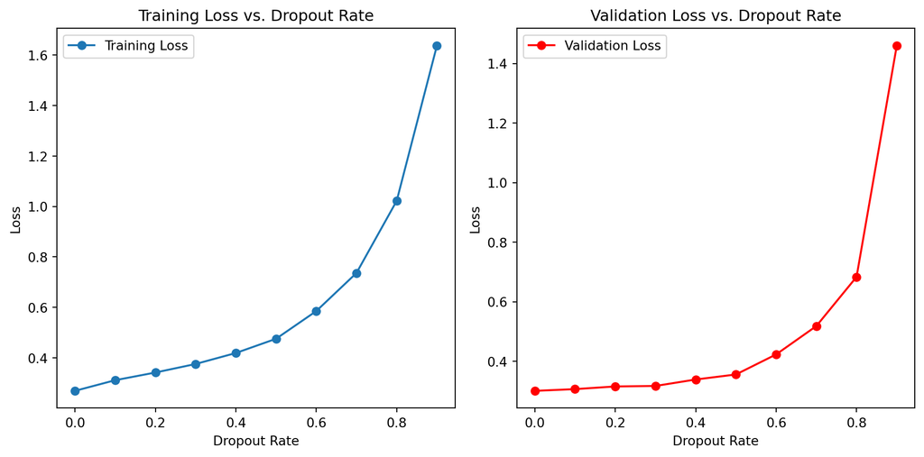

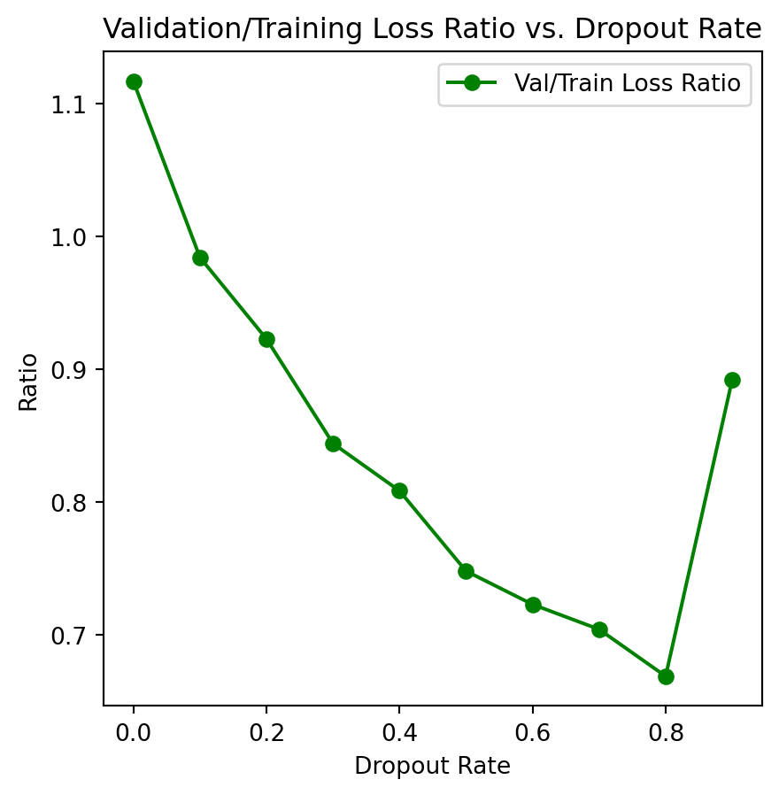

```python
#10 values for dropout
dropout_values = np.linspace(0, 0.9, 10)
results = defaultdict(dict)

ann_in_size = 28*28
ann_hidden_size = 96
ann_len = 3

for dropout_rate in dropout_values:
    start_time = time.time()

    #init based on hyperparameter choice 2
    model = FashionMNISTANN(input_size=ann_in_size, hidden_size=ann_hidden_size, output_shape=10, activation='sigmoid', num_layers=ann_len, dropout=dropout_rate)
    model.apply(lambda m: init_weights(m, init_type='xavier'))

    optimizer = 'rmsprop'

    #train
    trained_model, train_loss, val_loss = train_model(
        model,
        {'train': train_dataloader, 'val': val_dataloader},
        criterion=criterion,
        optimizer=optimizer,
        num_epochs=10,
        early_stopping_patience=5,
        visualize=False,
        l1_strength=0.0,
        l2_strength=0.0,
    )

    #save results
    results[dropout_rate]['train_loss'] = train_loss
    results[dropout_rate]['val_loss'] = val_loss

    #print elapsed time with two decimal places formated in mm:ss
    print(f'Elapsed Time: {time.strftime("%M:%S", time.gmtime(time.time() - start_time))}')

dropout_rates = np.array(list(results.keys()))
train_losses = np.array([results[rate]['train_loss'] for rate in dropout_rates])
val_losses = np.array([results[rate]['val_loss'] for rate in dropout_rates])

plt.figure(figsize=(10, 5))

#training loss plot
plt.subplot(1, 2, 1)
plt.plot(dropout_rates, train_losses, marker='o', label='Training Loss')
plt.xlabel('Dropout Rate')
plt.ylabel('Loss')
plt.title('Training Loss vs. Dropout Rate')
plt.legend()

#validation loss plot
plt.subplot(1, 2, 2)
plt.plot(dropout_rates, val_losses, marker='o', color='r', label='Validation Loss')
plt.xlabel('Dropout Rate')
plt.ylabel('Loss')
plt.title('Validation Loss vs. Dropout Rate')
plt.legend()

plt.tight_layout()
plt.show()

#plotting the ratio
ratio = val_losses / train_losses
plt.figure(figsize=(5, 5))
plt.plot(dropout_rates, ratio, marker='o', color='g', label='Val/Train Loss Ratio')
plt.xlabel('Dropout Rate')
plt.ylabel('Ratio')
plt.title('Validation/Training Loss Ratio vs. Dropout Rate')
plt.legend()
plt.show()
```

Hyperparameter Tuning 3

```
----------
train Loss: 0.4620
val Loss: 0.3269
[[495   0   6  20   3   0  56   0   3   0]
 [  0 566   0   2   0   0   2   0   0   0]
 [  5   0 540   3  18   0  13   0   0   0]
 [  4   2   2 608   6   0  14   0   0   0]
 [  0   0  19   9 569   0  20   0   0   0]
 [  0   0   0   0   0 597   0   6   0   1]
 [ 42   0  34  11  48   0 432   0   0   0]
 [  0   0   0   0   0   2   0 609   0   4]
 [  0   0   3   0   1   0   0   0 599   0]
 [  0   0   0   0   0   0   1  16   0 609]]
Elapsed Time: 01:08
----------
train Loss: 0.4833
val Loss: 0.3335
[[524   0   5  13   2   1  36   0   2   0]
 [  1 565   0   1   1   0   2   0   0   0]
 [  5   0 536   3  27   0   8   0   0   0]
 [  9   0   3 591  20   0  12   0   1   0]
 [  0   0  15   2 578   0  22   0   0   0]
 [  0   0   0   0   0 601   0   3   0   0]
 [ 64   0  29   7  50   0 417   0   0   0]
 [  0   0   0   0   0   6   0 602   0   7]
 [  2   0   1   0   2   2   0   0 596   0]
 [  0   0   0   0   0   2   0  19   0 605]]
Elapsed Time: 01:10
----------
train Loss: 0.5112
val Loss: 0.3088
[[504   0   7  19   0   1  47   1   4   0]
 [  0 567   0   2   1   0   0   0   0   0]
 [  3   0 540   5  10   0  20   0   1   0]
 [  6   3   2 611   7   0   7   0   0   0]
 [  0   1  17   9 555   0  34   0   1   0]
 [  0   0   0   0   0 601   0   3   0   0]
 [ 45   0  22  14  27   0 459   0   0   0]
 [  0   0   0   0   0   2   0 606   0   7]
 [  0   0   0   0   1   0   1   0 601   0]
```

[output cut: 85 more lines]

```
Elapsed Time: 01:10
----------
train Loss: 1.3925
val Loss: 0.9645
[[464   1  12  37   9   1  48   1  10   0]
 [  0 549   6  10   2   0   3   0   0   0]
 [  3   0 432   2 114   0  20   0   8   0]
 [ 18   4   2 566  26   0  20   0   0   0]
 [  2   0  22  41 538   0  13   0   1   0]
 [  0   0   0   0   0 451   0 122   1  30]
 [ 95   2  58  21 223   0 161   0   7   0]
 [  0   0   0   0   0   2   0 585   0  28]
 [  0   0   6   4   4   0   4   1 583   1]
 [  0   0   1   1   0   0   0  48   0 576]]
Elapsed Time: 01:10
```

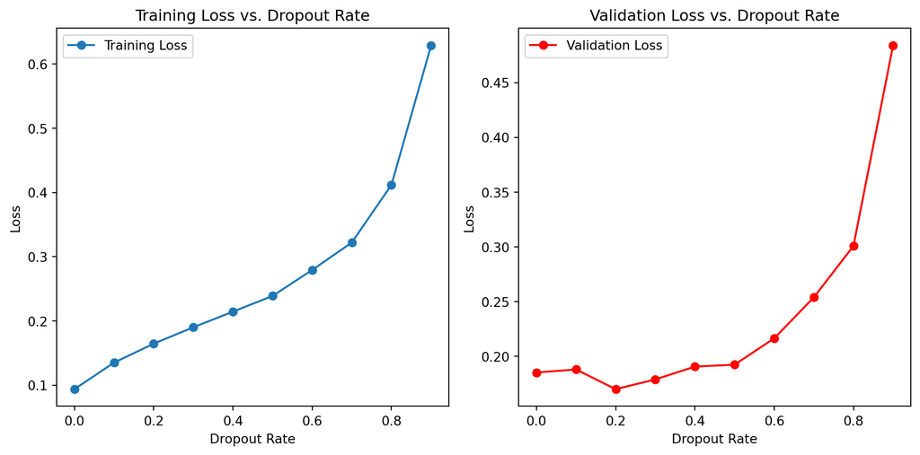

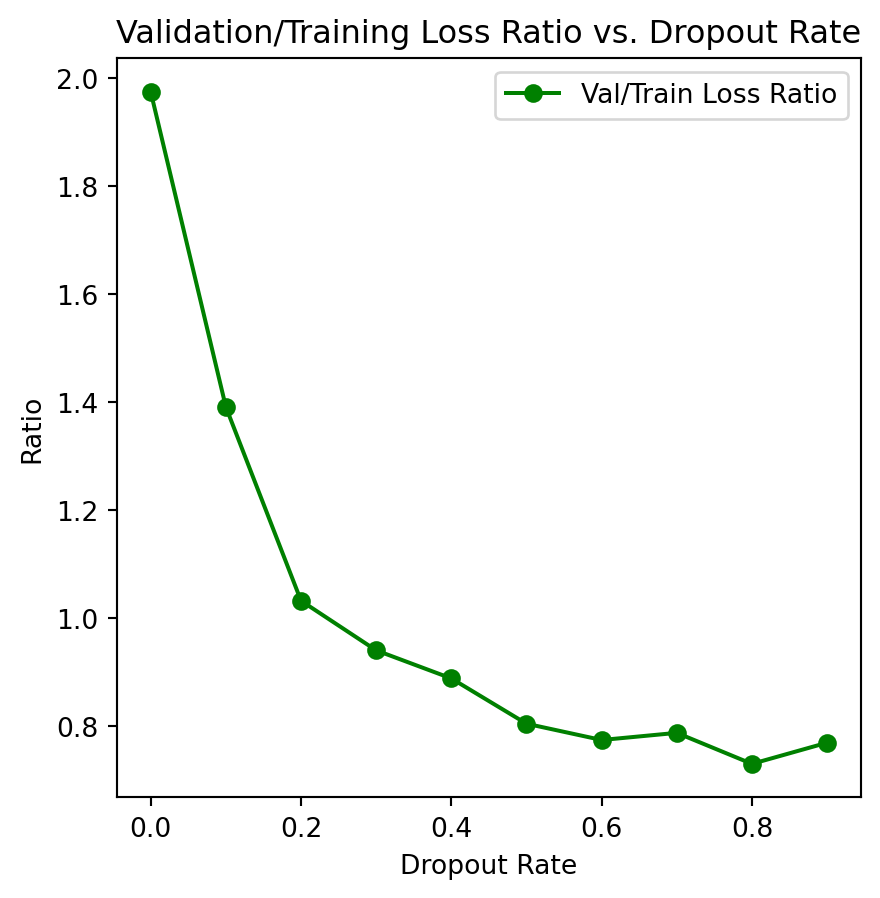

```python
#10 values for dropout
dropout_values = np.linspace(0, 0.9, 10)
results = defaultdict(dict)

for dropout_rate in dropout_values:
    start_time = time.time()

    #init based on hyperparameter choice 2
    model = FashionMNISTResNet(input_shape=1, channels=[96, 96, 96], output_shape=10, num_layers=2, activation='relu', dropout=dropout_rate)
    model.apply(lambda m: init_weights(m, init_type='xavier'))

    optimizer = 'adam'

    #train
    trained_model, train_loss, val_loss = train_model(
        model,
        {'train': train_dataloader, 'val': val_dataloader},
        criterion=criterion,
        optimizer=optimizer,
        num_epochs=10,
        early_stopping_patience=5,
        visualize=False,
        l1_strength=0.0,
        l2_strength=0.0,
    )

    #save results
    results[dropout_rate]['train_loss'] = train_loss
    results[dropout_rate]['val_loss'] = val_loss

    #print elapsed time with two decimal places formated in mm:ss
    print(f'Elapsed Time: {time.strftime("%M:%S", time.gmtime(time.time() - start_time))}')

dropout_rates = np.array(list(results.keys()))
train_losses = np.array([results[rate]['train_loss'] for rate in dropout_rates])
val_losses = np.array([results[rate]['val_loss'] for rate in dropout_rates])

plt.figure(figsize=(10, 5))

#training loss plot
plt.subplot(1, 2, 1)
plt.plot(dropout_rates, train_losses, marker='o', label='Training Loss')
plt.xlabel('Dropout Rate')
plt.ylabel('Loss')
plt.title('Training Loss vs. Dropout Rate')
plt.legend()

#validation loss plot
plt.subplot(1, 2, 2)
plt.plot(dropout_rates, val_losses, marker='o', color='r', label='Validation Loss')
plt.xlabel('Dropout Rate')
plt.ylabel('Loss')
plt.title('Validation Loss vs. Dropout Rate')
plt.legend()

plt.tight_layout()
plt.show()

#plotting the ratio
ratio = val_losses / train_losses
plt.figure(figsize=(5, 5))
plt.plot(dropout_rates, ratio, marker='o', color='g', label='Val/Train Loss Ratio')
plt.xlabel('Dropout Rate')
plt.ylabel('Ratio')
plt.title('Validation/Training Loss Ratio vs. Dropout Rate')
plt.legend()
plt.show()
```

```
----------
train Loss: 0.5089
val Loss: 0.3639
[[486   1   8  20   1   2  53   0  12   0]
 [  0 560   0   6   3   0   0   0   1   0]
 [  1   0 486   3  66   0  20   0   3   0]
 [ 12   2   7 571  38   0   6   0   0   0]
 [  2   0  40   5 547   0  21   0   2   0]
 [  0   0   0   1   0 576   0  11   1  15]
 [ 60   0  42  14  69   0 372   1   8   1]
 [  0   0   0   0   0  10   0 584   0  21]
 [  0   0   2   1   3   0   0   0 597   0]
 [  0   0   0   0   0   1   0  17   0 608]]
----------
train Loss: 0.5650
val Loss: 0.3791
[[467   1   7  10   0   0  88   0  10   0]
 [  1 558   1   9   0   0   0   0   1   0]
 [  2   1 469   3  77   0  23   0   4   0]
 [ 16   4   7 572  22   0  13   0   2   0]
 [  1   0  42  12 529   0  32   0   1   0]
 [  0   0   0   0   0 578   0  10   0  16]
 [ 52   1  44   5  57   1 400   0   6   1]
 [  0   0   0   0   0   5   0 574   0  36]
 [  0   0   0   1   2   0   2   0 597   1]
 [  0   0   0   0   0   2   0  12   0 612]]
----------
train Loss: 0.6397
val Loss: 0.3967
[[516   0   6  23   0   1  33   1   3   0]
 [  1 556   0  12   0   0   0   0   1   0]
 [  7   1 442   7  91   0  30   0   1   0]
 [ 18   1   3 592  12   0  10   0   0   0]
 [  2   0  35  32 512   0  35   0   1   0]
 [  0   0   0   0   0 583   0   9   0  12]
 [ 84   1  42  14  54   1 368   0   3   0]
 [  0   0   0   0   0  19   0 558   0  38]
 [  0   0   2   1   2   0   2   2 594   0]
 [  0   0   0   0   0   4   0  10   1 611]]
----------
```

[output cut: 75 more lines]

```
 [  0   0  12   0   0  22   0 495  70   4]
 [  0   0   0   0   0   1   0 623   2   0]]
----------
train Loss: 2.3361
val Loss: 2.3006
[[  0   0 583   0   0   0   0   0   0   0]
 [  0   0 570   0   0   0   0   0   0   0]
 [  0   0 579   0   0   0   0   0   0   0]
 [  0   0 636   0   0   0   0   0   0   0]
 [  0   0 616   0   0   0   0   0   0   1]
 [  0   0  43   0   0 470   0  82   0   9]
 [  0   0 567   0   0   0   0   0   0   0]
 [  0   0 527   0   0   3   0  61   0  24]
 [  0   0 596   0   0   0   0   6   0   1]
 [  0   0 581   0   0   4   0  32   0   9]]
```

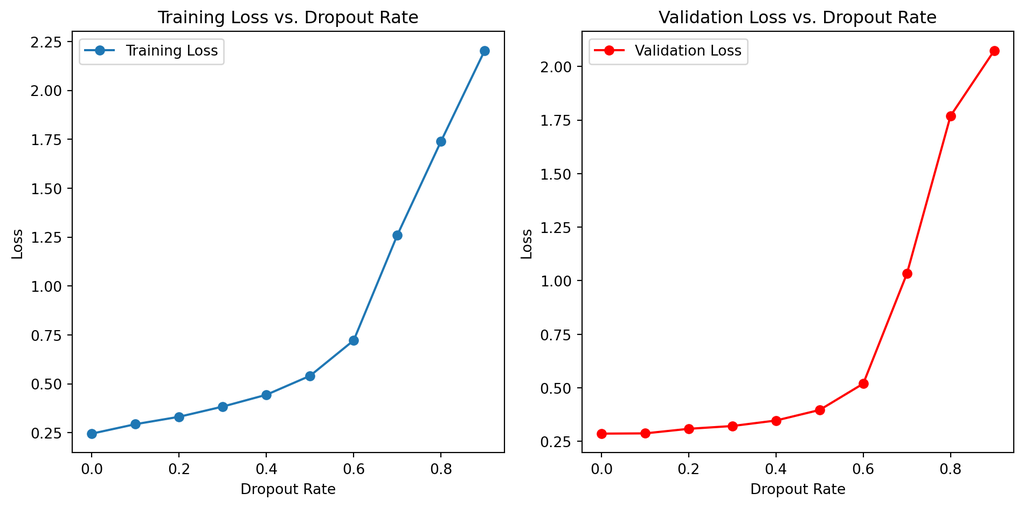

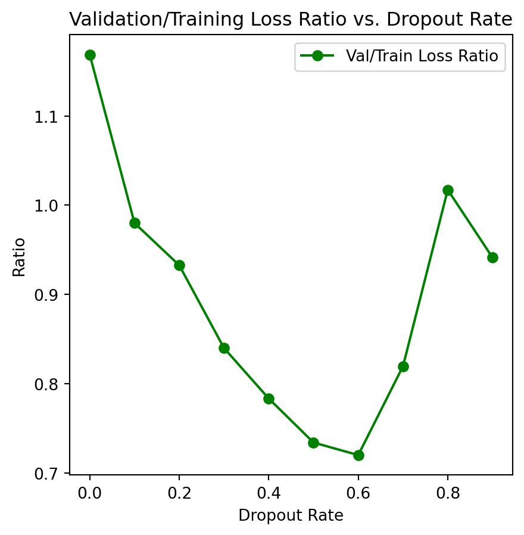

```python
#10 values for dropout
dropout_values = np.linspace(0, 0.9, 10)
results = defaultdict(dict)

ann_in_size = 28*28
ann_hidden_size = 96
ann_len = 3

for dropout_rate in dropout_values:
    #init based on hyperparameter choice 2
    model = FashionMNISTANN(input_size=ann_in_size, hidden_size=ann_hidden_size, output_shape=10, activation='relu', num_layers=ann_len, dropout=dropout_rate)
    model.apply(lambda m: init_weights(m, init_type='xavier'))

    optimizer = 'adam'

    #train
    trained_model, train_loss, val_loss = train_model(
        model,
        {'train': train_dataloader, 'val': val_dataloader},
        criterion=criterion,
        optimizer=optimizer,
        num_epochs=10,
        early_stopping_patience=5,
        visualize=False,
        l1_strength=0.0,
        l2_strength=0.0,
    )

    #save results
    results[dropout_rate]['train_loss'] = train_loss
    results[dropout_rate]['val_loss'] = val_loss

dropout_rates = np.array(list(results.keys()))
train_losses = np.array([results[rate]['train_loss'] for rate in dropout_rates])
val_losses = np.array([results[rate]['val_loss'] for rate in dropout_rates])

plt.figure(figsize=(10, 5))

#training loss plot
plt.subplot(1, 2, 1)
plt.plot(dropout_rates, train_losses, marker='o', label='Training Loss')
plt.xlabel('Dropout Rate')
plt.ylabel('Loss')
plt.title('Training Loss vs. Dropout Rate')
plt.legend()

#validation loss plot
plt.subplot(1, 2, 2)
plt.plot(dropout_rates, val_losses, marker='o', color='r', label='Validation Loss')
plt.xlabel('Dropout Rate')
plt.ylabel('Loss')
plt.title('Validation Loss vs. Dropout Rate')
plt.legend()

plt.tight_layout()
plt.show()

#plotting the ratio
ratio = val_losses / train_losses
plt.figure(figsize=(5, 5))
plt.plot(dropout_rates, ratio, marker='o', color='g', label='Val/Train Loss Ratio')
plt.xlabel('Dropout Rate')
plt.ylabel('Ratio')
plt.title('Validation/Training Loss Ratio vs. Dropout Rate')
plt.legend()
plt.show()
```

# Final Fit Model

Based on my hyperparameter tuning I’m going to use my resnet like model with a learning rate of .0001, dropout=.3, l1 and l2 regularization = 1.0e-4, relu activation, and the adam optimizer for 40 epochs. I also left my model itself with channel=32 and 2 hidden layers. Based on all of my hyperperameter tuning this should be s good model that avoids overfitting on the training set. Additionally, I’ll still be using things like early stopping and other hyperparameters that were used throughout the tuning process.

```
----------
train Loss: 1.5763
val Loss: 1.0336
----------
train Loss: 0.5150
val Loss: 0.4160
----------
train Loss: 0.4423
val Loss: 0.3645
----------
train Loss: 0.4100
val Loss: 0.3522
[[522   0   8  14   0   0  35   0   4   0]
 [  0 566   0   4   0   0   0   0   0   0]
 [  6   0 510   3  29   0  31   0   0   0]
 [ 19   2   3 595  10   0   7   0   0   0]
 [  3   3  21  17 536   0  37   0   0   0]
 [  0   0   0   0   0 589   0  14   0   1]
 [ 77   1  29  10  38   0 412   0   0   0]
 [  0   0   0   0   0   4   0 598   0  13]
 [  0   0   1   0   2   1   0   1 598   0]
 [  0   0   0   1   0   1   0  21   0 603]]
Training finished in 07:11
Accuracy of the model on the test set: 91.32%
```

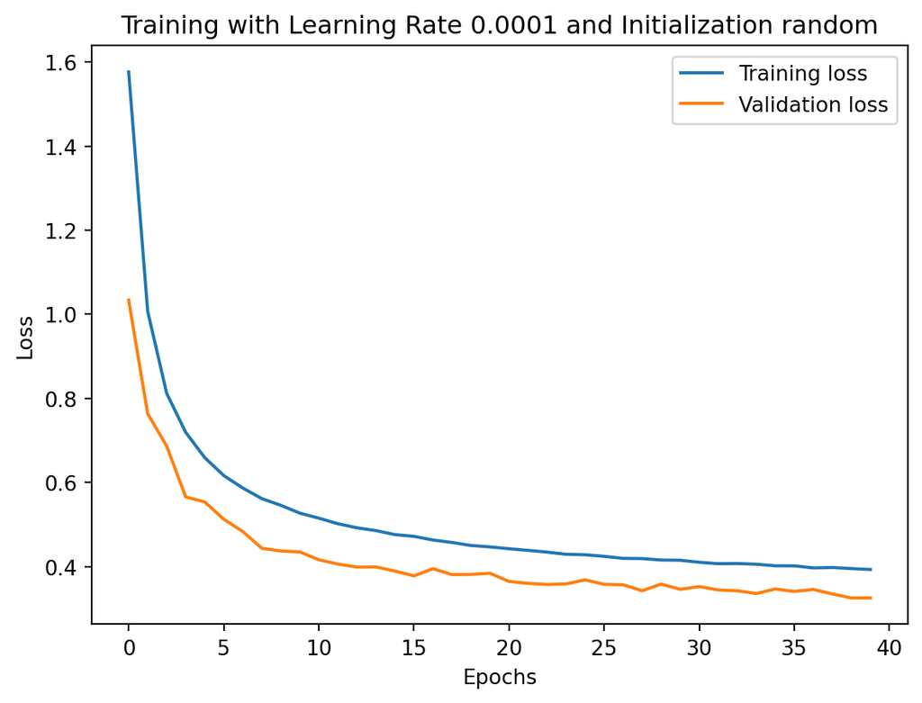

```python
lr = 0.0001
dropout = 0.3
l1_strength = 1.0e-4
l2_strength = 1.0e-4
activation = "relu"
num_epochs = 40
early_stopping_patience = 5

#initialize model
model = FashionMNISTResNet(input_shape=1, channels=[32, 32], output_shape=10, activation=activation, num_layers=2, dropout=dropout)

#init optimizer
optimizer = 'adam'


start_time = time.time()

#train
trained_model, train_loss, val_loss = train_model(model, {'train': train_dataloader, 'val': val_dataloader},
                                                   optimizer=optimizer,
                                                   criterion=nn.CrossEntropyLoss(),
                                                   num_epochs=num_epochs,
                                                   early_stopping_patience=early_stopping_patience,
                                                   l1_strength=l1_strength,
                                                   l2_strength=l2_strength,
                                                   lr=lr,
                                                   init_type='random',
                                                   visualize=True)

end_time = time.time()

#train time in mm:ss
print(f"Training finished in {time.strftime('%M:%S', time.gmtime(end_time - start_time))}")


#test
model.eval()
correct = 0
total = 0

with torch.no_grad():
    for images, labels in test_dataloader:
        images = images.to(device)
        labels = labels.to(device)
        outputs = model(images)
        _, predicted = torch.max(outputs.data, 1)
        total += labels.size(0)
        correct += (predicted == labels).sum().item()

test_accuracy = 100 * correct / total
print(f'Accuracy of the model on the test set: {test_accuracy:.2f}%')
```

# Bonus assignment

`+5 bonus points`

`You DO NOT need to do this if you don't want to`

- Once the data is collected, this HW should be quite easy, since most of the code can be recycled from the labs & textbook.
- Do this in a file called `bonus.ipynb`, have it save its results to a folder “data”

`Data collection`

- Develope a text based classification data-set:
- Use the Wikipedia API to search for articles to generate the data-set
- Select a set of highly different topics (i.e. labels), for example,
  - multi-class case: y=(pizza, oak_trees, basketball, … , etc)=(0,1,2, … , N-1)
  - You don’t have to use these, you can use whatever labels you want
  - `Have AT LEAST 10 labels.`
  - The more different the topics, the easier the classification task should be
- Search for Wikipedia pages about these topics and harvest the text from the pages.
- Do some basic text cleaning as needed.
  - e.g. use the NLTK sentence tokenizer to break the text into sentences.
  - Then form chunks of text that are five sentences long as your “inputs”.
- The “label” for these chunks will be the search label used to find the text.
- The data set will not be perfect.
  - There will be chunks of text that are not related to the topic (i.e. noise).
  - However that is just something we have to live with.
- **Important**: Always start small when writing & debugging THEN scale up.
- The more chunks of text you have the better.
  - Save the text and labels to the same format used by the textbook, that way you can recycle your lab code seamlessly.
- `Optional practice`: You can also “tag” each chunk of text with an associated “compound” sentiment score computed using the NLTK sentiment analysis. From this you can train a regression model in part-2. This is somewhat silly, and is just for educational purposes, since your using a model output to train another model.

`Model training`

- Repeat the model training and hyper-parameter tuning exercise for MNIST, but with your text.